# Inference for a Regression Slope

Lesson 33 — Simulation-Based Inference for Regression

Lt Col Cho

## Two samples of penguins

- **What is the true relationship between bill depth and flipper length?**

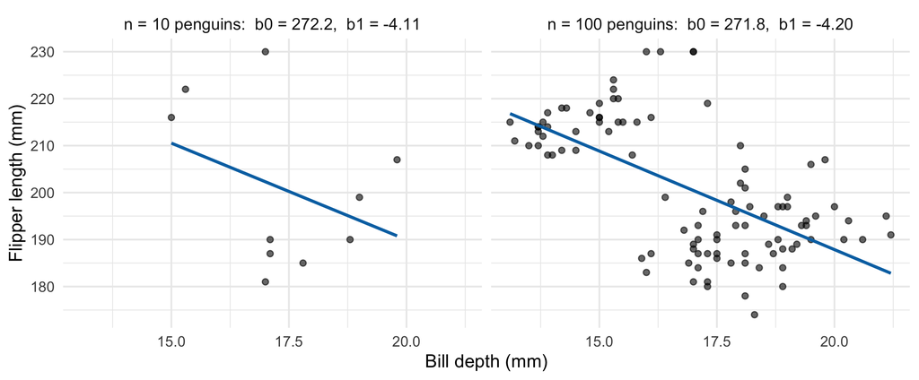

Two random samples of penguins: 10 penguins (left) and 100 penguins (right). Each line is the least squares line for that sample.

## Parameters and statistics in regression

|  | Population | Sample |
| --- | --- | --- |
| Model | $\text{flipper} = \beta_0 + \beta_1 \times \text{bill depth} + \varepsilon$ | $\widehat{\text{flipper}} = b_0 + b_1 \times \text{bill depth}$ |
| Intercept and slope | $\beta_0$, $\beta_1$: **parameters**, fixed and unknown | $b_0$, $b_1$: **statistics**, computed by least squares |
| Varies from sample to sample? | No | Yes |
| Block 3 analog | $\mu$, $p$ | $\bar{x}$, $\hat{p}$ |

- If there is truly no linear relationship between bill depth and flipper length, what should $\beta_1$ (and $\beta_0$) be?
- From the two samples: $b_1 = -4.11$ ($n = 10$) and $b_1 = -4.20$ ($n = 100$). What should we conclude about the relationship between bill depth and flipper length?

## How much do we trust the estimated coefficients?

- The fitted coefficients $b_0$ and $b_1$ are **point estimates** of $\beta_0$ and $\beta_1$: single values computed from one sample.
- Suppose drawing a new random sample of the same size could produce a very different value of $b_1$. How much should we trust the $b_1$ from our one sample?
- An inference about $\beta_1$ requires describing how much $b_1$ varies from sample to sample. With one sample, we approximate that variability by simulation:

|  | **Bootstrap CI** | **Permutation test** |
| --- | --- | --- |
| Question answered | What values of $\beta_1$ are plausible? | Is $b_1$ farther from 0 than expected if $\beta_1 = 0$? |
| What is randomized | Rows are resampled **with replacement** ($n$ rows) | The response values are **shuffled** across the $x$ values |
| $(x, y)$ pairs | Kept together | Broken apart |
| Assumes $\beta_1 = 0$? | No | Yes |
| Simulated distribution | Approximates the sampling distribution of $b_1$; centered near $b_1$ | Null distribution of $b_1$; centered near 0 |
| Result | **Confidence interval** for $\beta_1$ | **p-value** for $H_0: \beta_1 = 0$ |

## Bootstrap CI: resample penguins with replacement

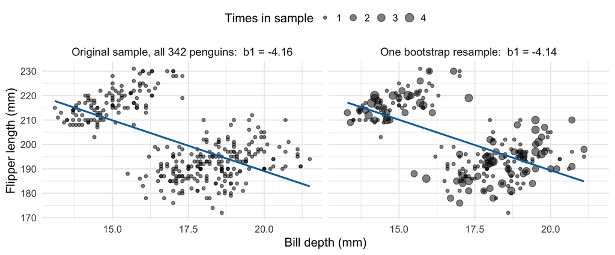

- The resample has 342 rows but only 226 distinct penguins: some appear 2 or more times, the rest not at all. Each penguin keeps **its own** bill depth and flipper length.

## Bootstrap CI: the distribution of 1,000 slopes

```r
set.seed(1)
penguin_boot <- penguins |>
  specify(flipper_length_mm ~ bill_depth_mm) |>
  generate(reps = 1000, type = "bootstrap") |>
  calculate(stat = "slope")

penguin_boot |> get_confidence_interval(level = 0.95, type = "percentile")
```

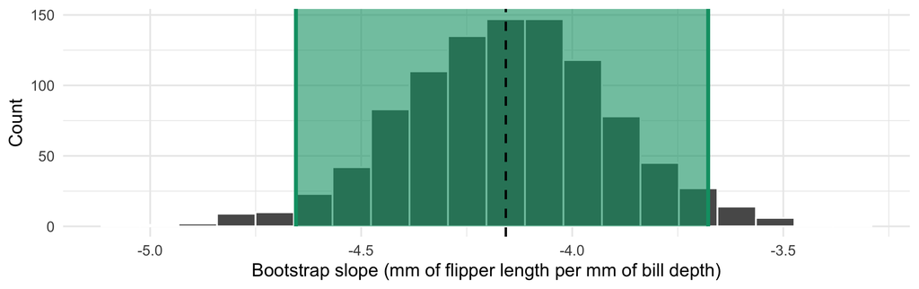

95% percentile interval: **(-4.65, -3.68)**, the middle 95% of the 1,000 bootstrap slopes. The dashed line is $b_1 = -4.157$.

## Bootstrap CI: interpreting the interval

- **What does (-4.65, -3.68) tell us about the population?**
- **Interpretation:** We are 95% confident that the population slope $\beta_1$ is between -4.65 and -3.68: for each additional mm of bill depth, mean flipper length is between 3.68 and 4.65 mm shorter.
- “95% confident” refers to the method: about 95% of intervals constructed this way contain $\beta_1$.
- It does **not** mean that 95% of penguins fall in this range, or that this particular interval contains $\beta_1$ with probability 0.95.
- **Does the interval contain 0?** No. Every plausible value of $\beta_1$ is negative, so $\beta_1 = 0$ is not plausible at the 95% level.

## Bootstrap CI: the effect of sample size

- **How does the 95% confidence interval change as the number of penguins in the sample increases?**

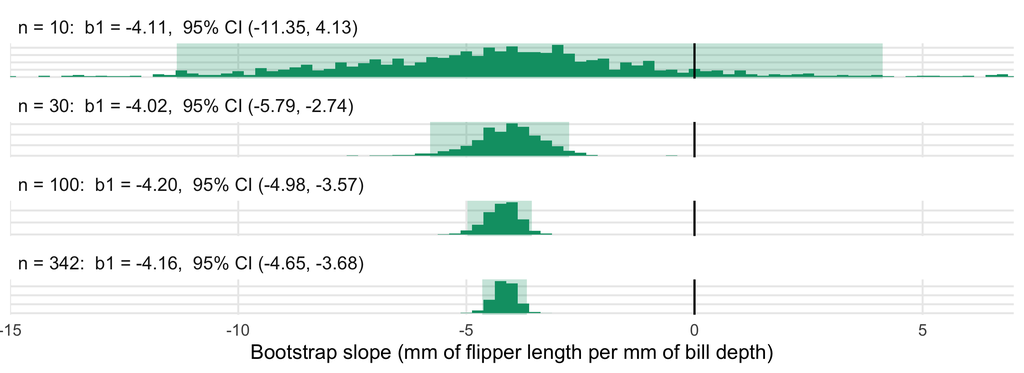

Nested random samples of 10, 30, 100, and all 342 penguins. Shaded: 95% CI. Black line: 0. A few $n = 10$ slopes lie outside the axis range.

$b_1$ is about the same at every $n$, but the interval is narrower for larger $n$. At $n = 10$ the interval contains 0.

## Permutation test: shuffle the response

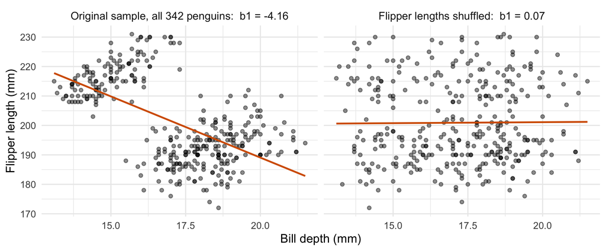

- The same 342 bill depths and the same 342 flipper lengths, randomly re-paired. In the shuffled data, flipper length is unrelated to bill depth: $H_0: \beta_1 = 0$ is true by construction.

## Permutation test: Steps 0–3

- **Step 0:** discernibility level $\alpha = 0.05$
- **Step 1:** $H_0: \beta_1 = 0$ (no linear relationship between bill depth and flipper length) vs. $H_A: \beta_1 \neq 0$
- **Step 2:** observed statistic $b_1 = -4.157$
- **Step 3:** build the null distribution and compute the p-value

```r
obs_slope <- penguins |>
  specify(flipper_length_mm ~ bill_depth_mm) |>
  calculate(stat = "slope") |>
  pull()

set.seed(1)
penguin_null <- penguins |>
  specify(flipper_length_mm ~ bill_depth_mm) |>
  hypothesize(null = "independence") |>
  generate(reps = 1000, type = "permute") |>
  calculate(stat = "slope")

penguin_null |> get_p_value(obs_stat = obs_slope, direction = "both")
```

## Permutation test: Step 4

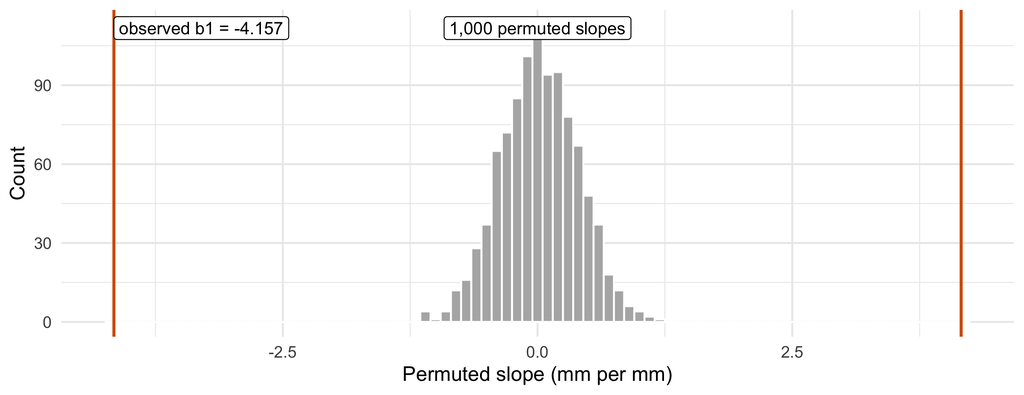

**Step 4:** 0 of 1,000 permuted slopes are at least as far from 0 as -4.157, so the **p-value < 0.001**. Reject $H_0$: the data provide statistically discernible evidence of a linear relationship between bill depth and flipper length.

## Permutation test: the effect of sample size

- **How does the p-value change as the number of penguins in the sample increases?**

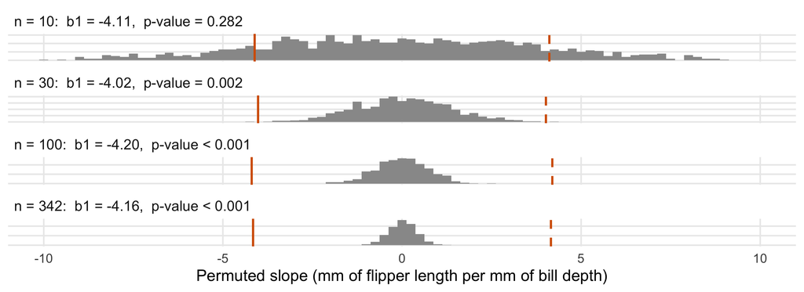

Same nested samples. Grey: null distribution of 1,000 permuted slopes. Orange lines: observed $b_1$ and its mirror image $-b_1$ (two-sided).

The observed slope is about the same at every $n$, but the null distribution is narrower for larger $n$, so the p-value is smaller. At $n = 10$, fail to reject $H_0$ at $\alpha = 0.05$.

## Which simulation should I use?

| If the question is… | Use | Result |
| --- | --- | --- |
| “How large is the slope? What values of $\beta_1$ are plausible?” | **Bootstrap CI** | Confidence interval for $\beta_1$ |
| “Is there evidence of a linear relationship ($\beta_1 \neq 0$)?” | **Permutation test** | p-value for $H_0: \beta_1 = 0$ |
| Either question about **one predictor in multiple regression** | **Bootstrap CI** | CI for that partial slope |

- With one predictor, a 95% CI that excludes 0 and a two-sided test that rejects $H_0: \beta_1 = 0$ at $\alpha = 0.05$ usually reach the same conclusion.

**Which method? (one predictor)**

1. By how many cm does mean height change per cm of shoulder girth?
2. Do the data provide evidence that hours of sleep are linearly related to GPA?
3. In the model `flipper_length_mm ~ bill_depth_mm + species`, is bill depth linearly related to flipper length after accounting for species?

## Same framework as Block 3

|  | Block 3: difference in means | Today: regression slope |
| --- | --- | --- |
| Parameter | $\mu_1 - \mu_2$ | $\beta_1$ |
| Statistic | $\bar{x}_1 - \bar{x}_2$ | $b_1$ |
| `calculate()` | `stat = "diff in means"` | `stat = "slope"` |
| Confidence interval | bootstrap rows → middle 95% | bootstrap rows → middle 95% |
| Null hypothesis | response unrelated to group | response unrelated to $x$ |
| Null distribution | shuffle the response | shuffle the response |

Only the statistic changed. The steps, code, and interpretations are the same.

## Bootstrap CI: partial slopes in multiple regression

**Fitted model** (parallel slopes, Lesson 31)

$$\widehat{\text{flipper}} = 136.949 + 2.889 \times \text{bill depth} + 5.655 \times \text{speciesChinstrap} + 36.953 \times \text{speciesGentoo}$$

```r
penguin_mult_boot <- penguins |>
  specify(flipper_length_mm ~ bill_depth_mm + species) |>
  generate(reps = 1000, type = "bootstrap") |>
  fit()                                   # fit() returns every coefficient
```

| Term | Estimate | 95% bootstrap CI |
| --- | --- | --- |
| `bill_depth_mm` | 2.889 | (2.41, 3.40) |
| `speciesChinstrap` | 5.655 | (3.86, 7.45) |
| `speciesGentoo` | 36.953 | (34.69, 39.04) |

- **Interpret the bill depth interval.** Does it contain 0? Compare it with the simple regression interval (-4.65, -3.68).

## Permutation test: caution in multiple regression

- **Iris:** `Petal.Width ~ Sepal.Width + Species`, partial slope for sepal width $b_1 = 0.283$.

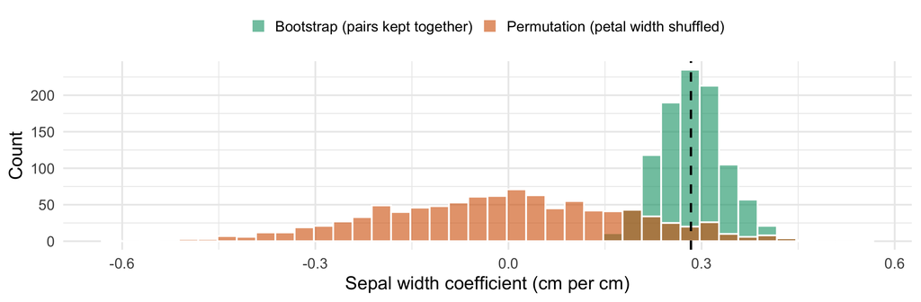

| Method | Result for sepal width |
| --- | --- |
| Bootstrap 95% CI | (0.190, 0.388): excludes 0 |
| Permutation p-value | 0.128: fail to reject at $\alpha = 0.05$ |

Shuffling the response removes its relationship with **every** predictor, so it tests “no relationship with any predictor,” not “this partial slope is 0.” For one partial slope, use the bootstrap CI.

## Practice: body measurements

- Height (cm) predicted from shoulder girth (cm) for 507 adults: $b_1 = 0.604$, standard error 0.030. 1,000 bootstrap slopes:

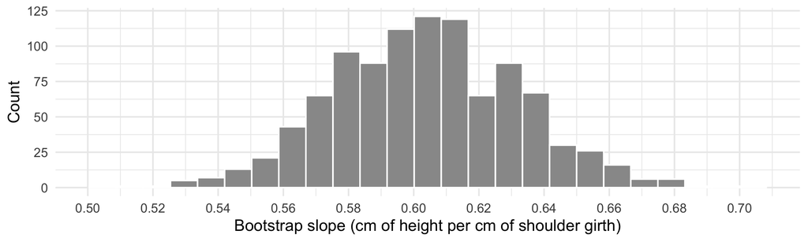

1. Estimate a 95% confidence interval for the population slope from the histogram.
2. Interpret the interval in context.
3. Write the interval as $b_1 \pm \text{MOE}$. What is the margin of error?
4. For a bell-shaped distribution, a 95% interval is about $b_1 \pm 2\,SE$. Estimate the standard error.
5. Compare your estimate with the standard error from the regression output.